# Lab_3

```python
from tensorflow.keras.preprocessing.image import ImageDataGenerator
import matplotlib.pyplot as plt
import random
from tensorflow.keras.preprocessing import image
import os
from tensorflow.keras import layers, models
from tensorflow.keras.optimizers import Adam
from tensorflow.keras.applications import VGG16
from tensorflow.keras import models, layers
from tensorflow.keras.callbacks import ModelCheckpoint
from sklearn.metrics import confusion_matrix, precision_score, recall_score, f1_score, precision_recall_curve
import seaborn as sns
import numpy as np
import matplotlib.pyplot as plt
from sklearn.metrics import precision_recall_curve
```

```python
# Dataset path
train_dir = "C:/Users/imana/Desktop/train_small/train"
validation_dir = "C:/Users/imana/Desktop/train_small/validation"
test_dir = "C:/Users/imana/Desktop/train_small/test"

# Initialiing the ImageDataGenerator for training, validation, and testing
train_datagen = ImageDataGenerator(
    rescale=1./255,  # Scaling the image values to [0, 1]
    rotation_range=40,  # Random rotations
    width_shift_range=0.2,  # Horizontal shifts
    height_shift_range=0.2,  # Vertical shifts
    shear_range=0.2,  # Shear transformations
    zoom_range=0.2,  # Random zoom
    horizontal_flip=True,  # Random horizontal flip
    fill_mode='nearest'  # Filling pixels after transformations
)

validation_datagen = ImageDataGenerator(rescale=1./255)  # rescaling only for validation and test
test_datagen = ImageDataGenerator(rescale=1./255)

# Loading the data using the flow_from_directory method
train_generator = train_datagen.flow_from_directory(
    train_dir,
    target_size=(150, 150),  # Resizing the images to 150x150
    batch_size=32,
    class_mode='binary',  # Binary classification (dog vs. cat)
    shuffle=True
)

validation_generator = validation_datagen.flow_from_directory(
    validation_dir,
    target_size=(150, 150),
    batch_size=32,
    class_mode='binary',
    shuffle=False  # not shuffling the validation data
)

test_generator = test_datagen.flow_from_directory(
    test_dir,
    target_size=(150, 150),
    batch_size=32,
    class_mode='binary',
    shuffle=False  # not shuffling the test data
)

# Confirming the dataset size
print("Train data:", train_generator.samples, "images")
print("Validation data:", validation_generator.samples, "images")
print("Test data:", test_generator.samples, "images")
```

```
Found 2000 images belonging to 2 classes.
Found 1000 images belonging to 2 classes.
Found 2000 images belonging to 2 classes.
Train data: 2000 images
Validation data: 1000 images
Test data: 2000 images
```

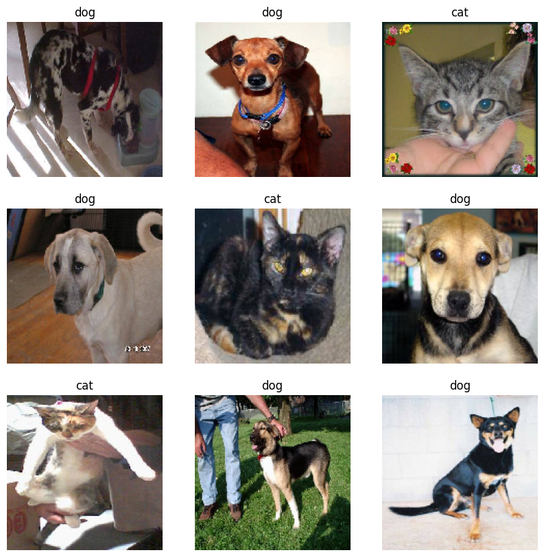

```python
# Visualising a few random images from both classes
plt.figure(figsize=(10, 10))
for i in range(9):
    plt.subplot(3, 3, i + 1)

    # Selecting a random class name (e.g., 'cats' or 'dogs')
    class_name = random.choice(list(train_generator.class_indices.keys()))

    # Getting the image path
    img_path = os.path.join(train_dir, class_name, random.choice(os.listdir(os.path.join(train_dir, class_name))))

    # Displaying the images
    img = image.load_img(img_path, target_size=(150, 150))
    plt.imshow(img)
    plt.title(class_name)
    plt.axis('off')

plt.show()
```

```python
# CNN model
def create_simple_cnn():
    model = models.Sequential([
        layers.Conv2D(32, (3, 3), activation='relu', input_shape=(150, 150, 3)),
        layers.MaxPooling2D((2, 2)),
        layers.Conv2D(64, (3, 3), activation='relu'),
        layers.MaxPooling2D((2, 2)),
        layers.Conv2D(64, (3, 3), activation='relu'),
        layers.Flatten(),
        layers.Dense(64, activation='relu'),
        layers.Dense(1, activation='sigmoid')
    ])

    model.compile(optimizer=Adam(), loss='binary_crossentropy', metrics=['accuracy'])
    return model

# Instantiating and summarising the model
cnn_model = create_simple_cnn()
cnn_model.summary()
```

```
Model: "sequential"
_________________________________________________________________
 Layer (type)                Output Shape              Param #
=================================================================
 conv2d (Conv2D)             (None, 148, 148, 32)      896

 max_pooling2d (MaxPooling2D  (None, 74, 74, 32)       0
 )

 conv2d_1 (Conv2D)           (None, 72, 72, 64)        18496

 max_pooling2d_1 (MaxPooling  (None, 36, 36, 64)       0
 2D)

 conv2d_2 (Conv2D)           (None, 34, 34, 64)        36928

 flatten (Flatten)           (None, 73984)             0

 dense (Dense)               (None, 64)                4735040

 dense_1 (Dense)             (None, 1)                 65

=================================================================
Total params: 4,791,425
Trainable params: 4,791,425
Non-trainable params: 0
_________________________________________________________________
```

```python
# Loading the pre-trained VGG16 model (excluding the top fully connected layers)
base_model = VGG16(weights='imagenet', include_top=False, input_shape=(150, 150, 3))

# Freezing the convolutional base
base_model.trainable = False

# Creating the full model by adding new top layers
model_vgg16 = models.Sequential([
    base_model,
    layers.Flatten(),
    layers.Dense(512, activation='relu'),
    layers.Dense(1, activation='sigmoid')
])

# Compiling the model
model_vgg16.compile(optimizer=Adam(), loss='binary_crossentropy', metrics=['accuracy'])
model_vgg16.summary()
```

```
Model: "sequential_1"
_________________________________________________________________
 Layer (type)                Output Shape              Param #
=================================================================
 vgg16 (Functional)          (None, 4, 4, 512)         14714688

 flatten_1 (Flatten)         (None, 8192)              0

 dense_2 (Dense)             (None, 512)               4194816

 dense_3 (Dense)             (None, 1)                 513

=================================================================
Total params: 18,910,017
Trainable params: 4,195,329
Non-trainable params: 14,714,688
_________________________________________________________________
```

```python
# Callback to save the best model during training
checkpoint_callback_cnn = ModelCheckpoint('best_model_cnn.h5', monitor='val_loss', save_best_only=True, mode='min')
checkpoint_callback_vgg16 = ModelCheckpoint('best_model_vgg16.h5', monitor='val_loss', save_best_only=True, mode='min')

# Training the CNN model and save the best weights
cnn_history = cnn_model.fit(
    train_generator,
    epochs=10,
    validation_data=validation_generator,
    callbacks=[checkpoint_callback_cnn]
)

# Training the VGG16 model and save the best weights
vgg16_history = model_vgg16.fit(
    train_generator,
    epochs=10,
    validation_data=validation_generator,
    callbacks=[checkpoint_callback_vgg16]
)
```

```
CNN Model - Loss: 0.6551897525787354, Accuracy: 0.5979999899864197
VGG16 Model - Loss: 0.24526502192020416, Accuracy: 0.8980000019073486
```

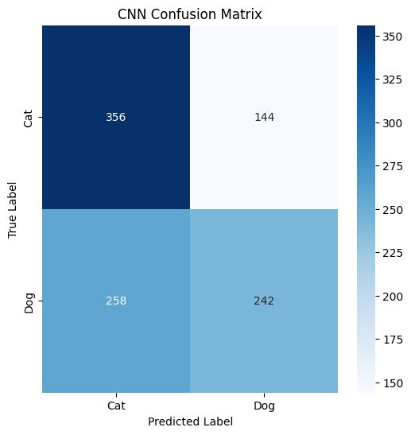

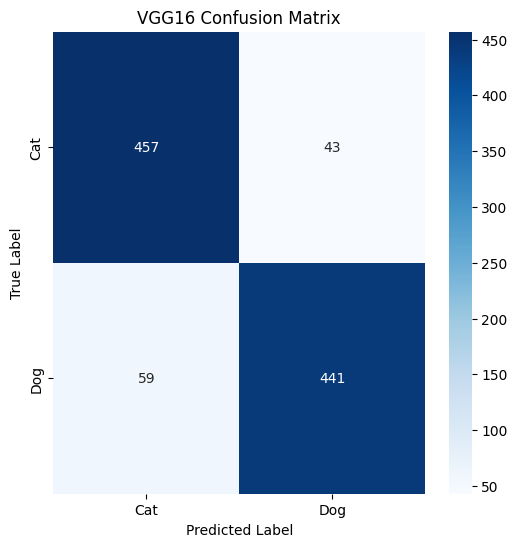

```
CNN Precision: 0.6269430051813472, Recall: 0.484, F1-score: 0.5462753950338601
VGG16 Precision: 0.9111570247933884, Recall: 0.882, F1-score: 0.8963414634146342
```

```python
# best weights for both models
cnn_model.load_weights('best_model_cnn.h5')
model_vgg16.load_weights('best_model_vgg16.h5')

# Evaluating both models on the validation data
cnn_eval = cnn_model.evaluate(validation_generator)
vgg16_eval = model_vgg16.evaluate(validation_generator)

# evaluation results
print(f"CNN Model - Loss: {cnn_eval[0]}, Accuracy: {cnn_eval[1]}")
print(f"VGG16 Model - Loss: {vgg16_eval[0]}, Accuracy: {vgg16_eval[1]}")

# predictions from both models
cnn_preds = cnn_model.predict(validation_generator)
vgg16_preds = model_vgg16.predict(validation_generator)

# Converting the predictions to binary labels (round to 0 or 1)
cnn_preds = cnn_preds.round()
vgg16_preds = vgg16_preds.round()

# Confusion matrix for CNN and VGG16
cnn_cm = confusion_matrix(validation_generator.classes, cnn_preds)
vgg16_cm = confusion_matrix(validation_generator.classes, vgg16_preds)

# confusion matrix plot for both models
def plot_confusion_matrix(cm, model_name):
    plt.figure(figsize=(6, 6))
    sns.heatmap(cm, annot=True, fmt='d', cmap='Blues', xticklabels=['Cat', 'Dog'], yticklabels=['Cat', 'Dog'])
    plt.title(f'{model_name} Confusion Matrix')
    plt.ylabel('True Label')
    plt.xlabel('Predicted Label')
    plt.show()

plot_confusion_matrix(cnn_cm, 'CNN')
plot_confusion_matrix(vgg16_cm, 'VGG16')

# Calculating the precision, recall, and F1-score for both models
cnn_precision = precision_score(validation_generator.classes, cnn_preds)
vgg16_precision = precision_score(validation_generator.classes, vgg16_preds)

cnn_recall = recall_score(validation_generator.classes, cnn_preds)
vgg16_recall = recall_score(validation_generator.classes, vgg16_preds)

cnn_f1 = f1_score(validation_generator.classes, cnn_preds)
vgg16_f1 = f1_score(validation_generator.classes, vgg16_preds)


print(f"CNN Precision: {cnn_precision}, Recall: {cnn_recall}, F1-score: {cnn_f1}")
print(f"VGG16 Precision: {vgg16_precision}, Recall: {vgg16_recall}, F1-score: {vgg16_f1}")
```

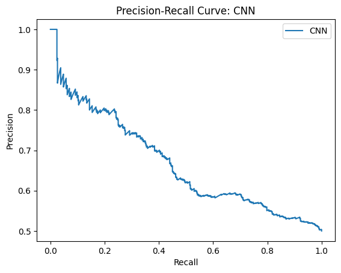

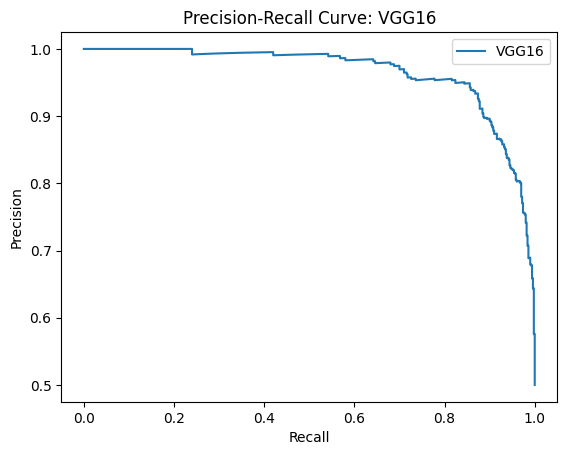

```python
# Precision-Recall curve
def plot_precision_recall_curve(y_true, y_pred, model_name):
    precision, recall, _ = precision_recall_curve(y_true, y_pred)
    plt.plot(recall, precision, label=model_name)
    plt.xlabel('Recall')
    plt.ylabel('Precision')
    plt.title(f'Precision-Recall Curve: {model_name}')
    plt.legend()
    plt.show()

# predicted probabilities for both models (not rounded)
cnn_preds_prob = cnn_model.predict(validation_generator)
vgg16_preds_prob = model_vgg16.predict(validation_generator)

# Precision-Recall curve for CNN model
plot_precision_recall_curve(validation_generator.classes, cnn_preds_prob, 'CNN')

# Precision-Recall curve for VGG16 model
plot_precision_recall_curve(validation_generator.classes, vgg16_preds_prob, 'VGG16')
```

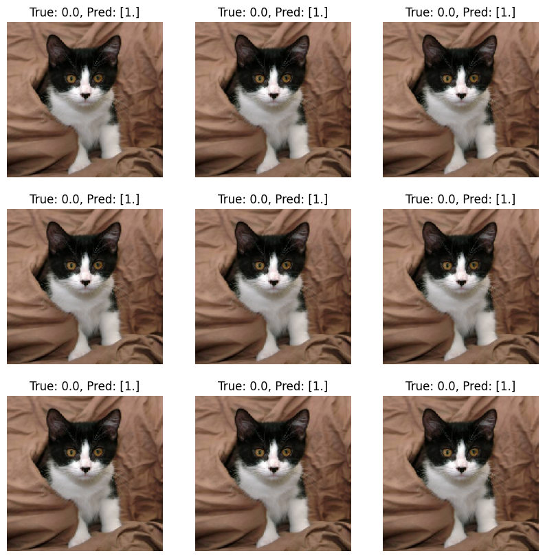

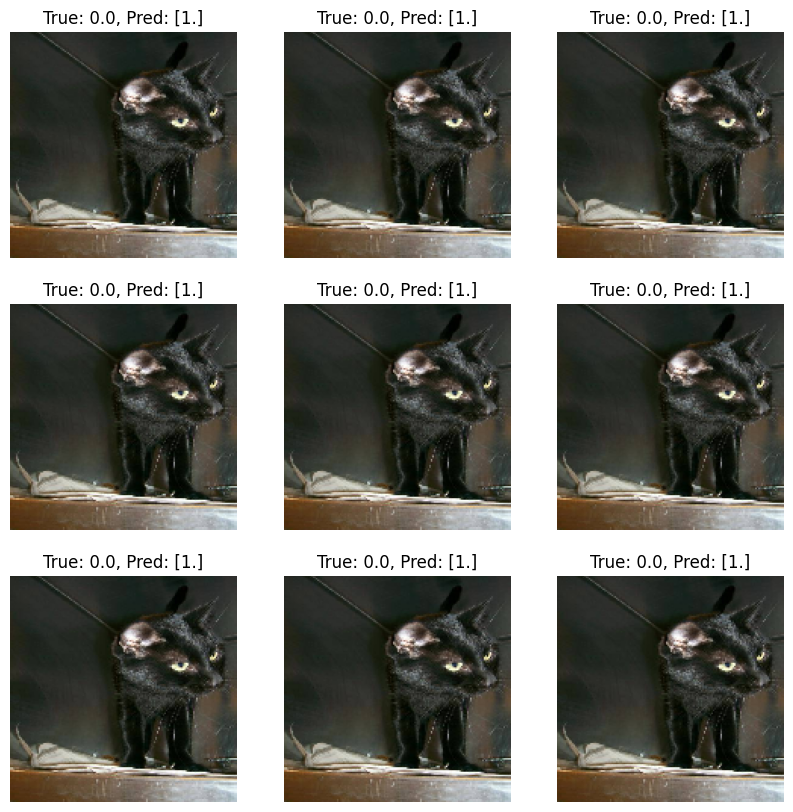

```python
def show_failed_predictions(model, data_gen):
    # Geting a batch from the data generator
    data, labels = next(data_gen)  # Get one batch of data and labels

    # Predictions on the data
    predictions = model.predict(data)

    # Getting the indices where the prediction is incorrect
    wrong_preds = np.where(predictions.round() != labels)[0]

    plt.figure(figsize=(10, 10))
    for i, idx in enumerate(wrong_preds[:9]):  # Show up to 9 failed predictions
        plt.subplot(3, 3, i + 1)

        # Get the actual image from the batch
        img = data[idx]  # `data[idx]` is an image in the batch, it should be of shape (150, 150, 3)

        # Display the image
        plt.imshow(img)
        plt.title(f"True: {labels[idx]}, Pred: {predictions[idx].round()}")
        plt.axis('off')

    plt.show()

show_failed_predictions(cnn_model, validation_generator)
show_failed_predictions(model_vgg16, validation_generator)
```

**Model performance comparison:**

**Incorrect Predictions:**

Potential Causes of Inaccurate Classification:

- Model Training: Inadequate training or inadequate model complexity may have contributed to the CNN model's poor performance. Unbalanced representations of cats vs dogs in the dataset, as well as other data-related problems like incorrect augmentation, may be present.
- Images with inherent ambiguity may depict cats with backdrops or attributes that give them a dog-like appearance (for example, black cats with deeper tones may confound CNN).

**Areas for Improvement:**

1. CNN Model: There are several ways to enhance the CNN model.
   - Adding more layers, units, and other components to the model increases its complexity.
   - improving the augmentation methods and adding more epochs to the model.
   - Better feature extraction and transfer learning may be achieved by using pre-trained models such as VGG16 or ResNet.
2. VGG16 Model: The VGG16 model is operating effectively at the moment. Nonetheless, some possible topics to investigate are:
   - By unfreezing a few of its top layers and doing further dataset training, the VGG16 model may be improved.
   - utilizing more sophisticated augmentation methods or experimenting with other pre-trained models, such as ResNet or Inception.

**Conclusion:**

- The accuracy, recall, and F1-score of the VGG16 model demonstrate how much better it performs than the CNN model.
- To enhance performance, the CNN model could profit from more training, modifications to the architecture, or data augmentation.
- The main cause of visual misclassifications is the difficulty in distinguishing cats from dogs in pictures that may have overlapping characteristics.